# Wholesale Consumer Segmentation with R

### 1. Business Problem

Company XYZ is a wholesale distributor that serves a number of business clients(e.g., retailers, restaurant, hotels, or cafes) in Portugal.The management of XYZ would like to get a deeper understanding of the spending patterns of their clients, so that they can make strategic decisions to better meet the clients’ demand.

#### 1.1 Business Task:

• Identify meaningful spending patterns of Company XYZ’s wholesale clients and come up with strategies that better meet their client’s demand.

### 2. Prepare Data

#### 2.1 About the data

• Wholesale customers dataset from Company XYZ • The dataset consists of 440 clients and their annual spending • Each record corresponds to a client, and contains a client’s region, channel, and annual spending across 6 product categories: • Channel 1. Horeca (Hotel/Restaurant/Cafe) 2. Retail • Region 1. Lisbon 2. Oporto 3. other regions • Product categories 1. Fresh 2. Milk 3. Grocery 4. Frozen 5. Detergents_Paper 6. Delicatessen

### 3. Process Data

#### 3.1 Import data and required packages

```r
library(dplyr)
library(arules)
library(stats)
library(cluster)
library(ggplot2)
library(factoextra)
library(skimr)
library(tidyr)
library(tinytex)
```

```r
# import the dataset
wholesale = read.csv("Wholesale customers data.csv")

# Get summary of data to look at quartile
summary(wholesale)
```

```
TRUE     Channel          Region          Fresh             Milk
TRUE  Min.   :1.000   Min.   :1.000   Min.   :     3   Min.   :   55
TRUE  1st Qu.:1.000   1st Qu.:2.000   1st Qu.:  3128   1st Qu.: 1533
TRUE  Median :1.000   Median :3.000   Median :  8504   Median : 3627
TRUE  Mean   :1.323   Mean   :2.543   Mean   : 12000   Mean   : 5796
TRUE  3rd Qu.:2.000   3rd Qu.:3.000   3rd Qu.: 16934   3rd Qu.: 7190
TRUE  Max.   :2.000   Max.   :3.000   Max.   :112151   Max.   :73498
TRUE     Grocery          Frozen        Detergents_Paper   Delicatessen
TRUE  Min.   :    3   Min.   :   25.0   Min.   :    3.0   Min.   :    3.0
TRUE  1st Qu.: 2153   1st Qu.:  742.2   1st Qu.:  256.8   1st Qu.:  408.2
TRUE  Median : 4756   Median : 1526.0   Median :  816.5   Median :  965.5
TRUE  Mean   : 7951   Mean   : 3071.9   Mean   : 2881.5   Mean   : 1524.9
TRUE  3rd Qu.:10656   3rd Qu.: 3554.2   3rd Qu.: 3922.0   3rd Qu.: 1820.2
TRUE  Max.   :92780   Max.   :60869.0   Max.   :40827.0   Max.   :47943.0
```

- From the summary, we get the Q1, Median, and Q3 for each product categories.

#### 3.2 Data Exploration

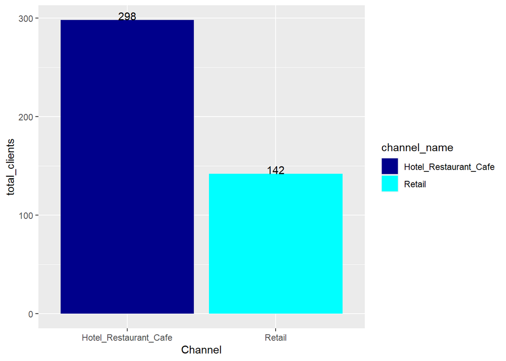

```r
channel_count=wholesale %>%
  mutate(channel_name = case_when(Channel==1 ~ 'Hotel_Restaurant_Cafe',
                                  Channel==2 ~ 'Retail')) %>%
  group_by(channel_name) %>% summarise(n=n())

# Plotting clients count vs channels
ggplot(channel_count, aes(y=n,x=channel_name,fill=channel_name))+
  geom_bar(stat='identity' ) +
  scale_fill_manual(values = c('darkblue','cyan'))+
  labs(x='Channel', y='total_clients')+
  geom_text(aes(label=n),vjust=0)
```

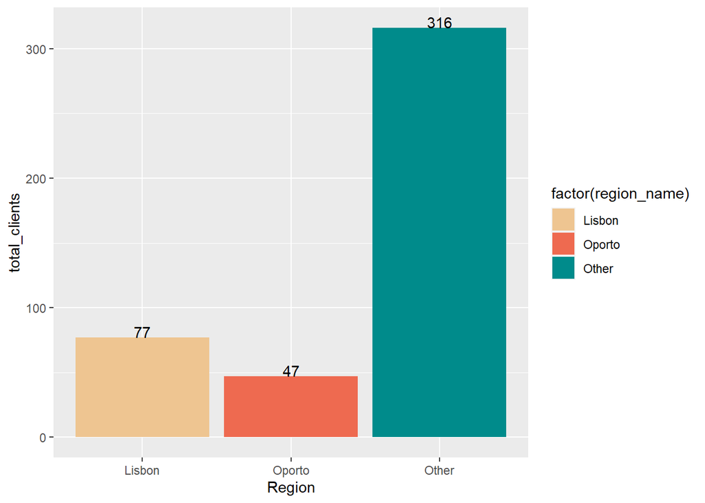

```r
# Plotting clients count vs region
region_count=wholesale %>%
  mutate(region_name = case_when(Region==1 ~ 'Lisbon',Region==2 ~ 'Oporto',
                                 Region==3 ~ 'Other')) %>%
           group_by(region_name) %>% summarise(n=n())

ggplot(region_count, aes(y=n,x=as.character(region_name),fill=factor(region_name)))+
  geom_bar(stat='identity' ) +
  scale_fill_manual(values = c('burlywood2','coral2','darkcyan'))+
  labs(x='Region', y='total_clients')+
  geom_text(aes(label=n),vjust=0)
```

Overall, we found that the majority of the clients are from the ‘Other’ region and most of the clients are from the Horeca channel. To further understand the relationships within the data and the grouping of the clients for focused targeting, association rules and clustering analysis have been performed.

### 4. Analyzing Data

#### 4.1 Association Rule

This is a technique that helps uncover interesting co-occurrence and co-purchase habits. We are mainly focusing on the high spending clients (top 25% annual spending for each product category), since they are the clients who bring in the majority of the revenue (62%).

```r
# 1. Utilizing association rules to identify if there's any meaningful
#relationship between:
#- Annual spending of each product categories
#- Channel and spending of each product
#- between products

#To do that, we first need to transform them into binary variables:
#  - round(Min - Q1): considered as low spending
# - round(Q1 - Q3): considered as medium spending
# - round(Q3 - Max): considered as high spending

# Convert all variables to binary variable in order to use Arules package.
wholesale_convert = wholesale %>%
  mutate(RLisbon = ifelse(Region == 1, 1, 0),
         ROporto = ifelse(Region == 2, 1, 0),
         ROther = ifelse(Region == 3, 1, 0)) %>%

  mutate(CHoreca = ifelse(Channel == 1, 1, 0),
         CRetail = ifelse(Channel == 2, 1, 0)) %>%

  mutate(FreshH = ifelse(Fresh > 17000, 1, 0),
         FreshM = ifelse(Fresh <= 17000 & Fresh > 3100, 1, 0),
         FreshL = ifelse(Fresh <= 3100, 1, 0)) %>%

  mutate(MilkH = ifelse(Milk > 7200, 1, 0),
         MilkM = ifelse(Milk <= 7200 & Milk > 1500, 1, 0),
         MilkL = ifelse(Milk <= 1500, 1, 0)) %>%

  mutate(GroceryH = ifelse(Grocery > 11000, 1, 0) ,
         GroceryM = ifelse(Grocery <= 11000 & Grocery > 2200, 1, 0),
         GroceryL = ifelse(Grocery <= 2200, 1, 0)) %>%

  mutate(FrozenH = ifelse(Frozen > 4000, 1, 0),
         FrozenM = ifelse(Frozen <= 4000 & Frozen > 800, 1, 0),
         FrozenL = ifelse(Frozen <= 800, 1, 0)) %>%

  mutate(DetergentsH = ifelse(Detergents_Paper > 4000, 1, 0),
         DetergentsM = ifelse(Detergents_Paper <= 4000 & Detergents_Paper > 300,
                              1, 0),
         DetergentsL = ifelse(Detergents_Paper <= 300, 1, 0)) %>%

  mutate(DelicatessenH = ifelse(Delicatessen > 1900, 1, 0),
         DelicatessenM = ifelse(Delicatessen <= 1900 & Delicatessen > 410, 1, 0),
         DelicatessenL = ifelse(Delicatessen <= 410, 1, 0))

whs_convertion = wholesale_convert[,9:31]
```

To obtain a meaningful amount of association rules, we need to set a minimum support and confidence.For this data set, we set a minimum support of 20% and a minimum confidence of 70%. If no rules are obtained, support% will be reduced to see if any meaningful rules can be found.

- support percentage:fraction of transactions containing both attributes within the data set
- confidence: the ratio of transactions having attribute A that also contains the attribute B

```r
# When minsupport at 20% and minconfidence at 70%:
whs = whs_convertion %>% mutate(across(,as.logical))
whs_rules = apriori(whs,
                    parameter = list(supp=0.2,conf=0.7, minlen = 2))
```

```
## Apriori
##
## Parameter specification:
##  confidence minval smax arem  aval originalSupport maxtime support minlen
##         0.7    0.1    1 none FALSE            TRUE       5     0.2      2
##  maxlen target  ext
##      10  rules TRUE
##
## Algorithmic control:
##  filter tree heap memopt load sort verbose
##     0.1 TRUE TRUE  FALSE TRUE    2    TRUE
##
## Absolute minimum support count: 88
##
## set item appearances ...[0 item(s)] done [0.00s].
## set transactions ...[23 item(s), 440 transaction(s)] done [0.00s].
## sorting and recoding items ... [21 item(s)] done [0.00s].
## creating transaction tree ... done [0.00s].
## checking subsets of size 1 2 3 4 done [0.00s].
## writing ... [39 rule(s)] done [0.00s].
## creating S4 object  ... done [0.00s].
```

```r
inspect(sort(whs_rules, by ='lift'))
```

```
##      lhs                          rhs           support   confidence coverage
## [1]  {DetergentsH}             => {CRetail}     0.2272727 0.9174312  0.2477273
## [2]  {CRetail}                 => {DetergentsH} 0.2272727 0.7042254  0.3227273
## [3]  {MilkM, DetergentsM}      => {GroceryM}    0.2340909 0.7862595  0.2977273
## [4]  {MilkM, GroceryM}         => {DetergentsM} 0.2340909 0.7054795  0.3318182
## [5]  {ROther, GroceryM}        => {DetergentsM} 0.2500000 0.7006369  0.3568182
## [6]  {GroceryL}                => {CHoreca}     0.2590909 1.0000000  0.2590909
## [7]  {DetergentsL}             => {CHoreca}     0.2840909 1.0000000  0.2840909
## [8]  {ROther, DetergentsL}     => {CHoreca}     0.2022727 1.0000000  0.2022727
## [9]  {DetergentsM}             => {GroceryM}    0.3477273 0.7427184  0.4681818
## [10] {ROther, DetergentsM}     => {GroceryM}    0.2500000 0.7382550  0.3386364
## [11] {MilkL}                   => {CHoreca}     0.2386364 0.9722222  0.2454545
## [12] {CHoreca, DetergentsM}    => {GroceryM}    0.2636364 0.7073171  0.3727273
## [13] {MilkM, DetergentsM}      => {CHoreca}     0.2386364 0.8015267  0.2977273
## [14] {DetergentsM}             => {CHoreca}     0.3727273 0.7961165  0.4681818
```

[output cut: 65 more lines]

We start by looking at the data region by region to find any patterns in the associations.

```r
wholesale_Lisbon = whs_convertion %>% filter(RLisbon == 1)
wholesale_Oporto = whs_convertion %>% filter(ROporto == 1)
wholesale_Other = whs_convertion %>% filter(ROther == 1)

# Region LisbonH support, confidence, and lift (still using overall data's high,
# medium, and low levels):
LisbonH = wholesale_Lisbon %>% select(CHoreca, CRetail, FreshH, MilkH, GroceryH,
                                      FrozenH, DetergentsH, DelicatessenH)
LisbonH = LisbonH %>% mutate(across(,as.logical))
LisbonH_rules = apriori(LisbonH, parameter = list(supp=0.15,conf=0.7))
```

```
TRUE Apriori
TRUE
TRUE Parameter specification:
TRUE  confidence minval smax arem  aval originalSupport maxtime support minlen
TRUE         0.7    0.1    1 none FALSE            TRUE       5    0.15      1
TRUE  maxlen target  ext
TRUE      10  rules TRUE
TRUE
TRUE Algorithmic control:
TRUE  filter tree heap memopt load sort verbose
TRUE     0.1 TRUE TRUE  FALSE TRUE    2    TRUE
TRUE
TRUE Absolute minimum support count: 11
TRUE
TRUE set item appearances ...[0 item(s)] done [0.00s].
TRUE set transactions ...[8 item(s), 77 transaction(s)] done [0.00s].
TRUE sorting and recoding items ... [8 item(s)] done [0.00s].
TRUE creating transaction tree ... done [0.00s].
TRUE checking subsets of size 1 2 3 done [0.00s].
TRUE writing ... [17 rule(s)] done [0.00s].
TRUE creating S4 object  ... done [0.00s].
```

```r
inspect(sort(LisbonH_rules, by ='lift'))
```

```
TRUE      lhs                        rhs           support   confidence coverage
TRUE [1]  {MilkH, DetergentsH}    => {GroceryH}    0.1558442 0.9230769  0.1688312
TRUE [2]  {CRetail, GroceryH}     => {DetergentsH} 0.1688312 1.0000000  0.1688312
TRUE [3]  {CRetail, DetergentsH}  => {GroceryH}    0.1688312 0.8666667  0.1948052
TRUE [4]  {GroceryH, DetergentsH} => {CRetail}     0.1688312 0.9285714  0.1818182
TRUE [5]  {DetergentsH}           => {GroceryH}    0.1818182 0.7777778  0.2337662
TRUE [6]  {GroceryH}              => {DetergentsH} 0.1818182 0.8750000  0.2077922
TRUE [7]  {MilkH, GroceryH}       => {DetergentsH} 0.1558442 0.8571429  0.1818182
TRUE [8]  {CRetail}               => {DetergentsH} 0.1948052 0.8333333  0.2337662
TRUE [9]  {DetergentsH}           => {CRetail}     0.1948052 0.8333333  0.2337662
TRUE [10] {GroceryH}              => {CRetail}     0.1688312 0.8125000  0.2077922
TRUE [11] {CRetail}               => {GroceryH}    0.1688312 0.7222222  0.2337662
TRUE [12] {GroceryH}              => {MilkH}       0.1818182 0.8750000  0.2077922
TRUE [13] {GroceryH, DetergentsH} => {MilkH}       0.1558442 0.8571429  0.1818182
TRUE [14] {DetergentsH}           => {MilkH}       0.1688312 0.7222222  0.2337662
TRUE [15] {FreshH}                => {CHoreca}     0.2077922 0.9411765  0.2207792
TRUE [16] {FrozenH}               => {CHoreca}     0.2207792 0.8095238  0.2727273
TRUE [17] {}                      => {CHoreca}     0.7662338 0.7662338  1.0000000
TRUE      lift     count
TRUE [1]  4.442308 12
TRUE [2]  4.277778 13
TRUE [3]  4.170833 13
TRUE [4]  3.972222 13
TRUE [5]  3.743056 14
TRUE [6]  3.743056 14
TRUE [7]  3.666667 12
TRUE [8]  3.564815 15
TRUE [9]  3.564815 15
TRUE [10] 3.475694 13
TRUE [11] 3.475694 13
TRUE [12] 3.208333 14
TRUE [13] 3.142857 12
TRUE [14] 2.648148 13
TRUE [15] 1.228315 16
TRUE [16] 1.056497 17
TRUE [17] 1.000000 59
```

Across all region, high spending clients from Retail who buy products from Grocery are 3 times more likely to purchase products from the Detergents category and vice versa than pure chance.

High spending clients who buy products from Grocery and Detergents are 3 times more likely to be from the Retail channel.

```r
# Region OportoH support, confidence, and lift (still using overall data's high,
#medium, and low levels):
OportoH = wholesale_Oporto %>% select(CHoreca, CRetail, FreshH, MilkH, GroceryH,
                                      FrozenH, DetergentsH, DelicatessenH)
OportoH = OportoH %>% mutate(across(,as.logical))
OportoH_rules = apriori(OportoH,
                        parameter = list(supp=0.1,conf=0.7))
```

```
TRUE Apriori
TRUE
TRUE Parameter specification:
TRUE  confidence minval smax arem  aval originalSupport maxtime support minlen
TRUE         0.7    0.1    1 none FALSE            TRUE       5     0.1      1
TRUE  maxlen target  ext
TRUE      10  rules TRUE
TRUE
TRUE Algorithmic control:
TRUE  filter tree heap memopt load sort verbose
TRUE     0.1 TRUE TRUE  FALSE TRUE    2    TRUE
TRUE
TRUE Absolute minimum support count: 4
TRUE
TRUE set item appearances ...[0 item(s)] done [0.00s].
TRUE set transactions ...[8 item(s), 47 transaction(s)] done [0.00s].
TRUE sorting and recoding items ... [8 item(s)] done [0.00s].
TRUE creating transaction tree ... done [0.00s].
TRUE checking subsets of size 1 2 3 4 done [0.00s].
TRUE writing ... [24 rule(s)] done [0.00s].
TRUE creating S4 object  ... done [0.00s].
```

```r
inspect(sort(OportoH_rules, by ='lift'))
```

```
TRUE      lhs                                 rhs           support   confidence
TRUE [1]  {MilkH, DetergentsH}             => {GroceryH}    0.1489362 1.0000000
TRUE [2]  {CRetail, MilkH, DetergentsH}    => {GroceryH}    0.1489362 1.0000000
TRUE [3]  {CRetail, GroceryH}              => {MilkH}       0.1702128 0.7272727
TRUE [4]  {GroceryH, DetergentsH}          => {MilkH}       0.1489362 0.7000000
TRUE [5]  {CRetail, GroceryH, DetergentsH} => {MilkH}       0.1489362 0.7000000
TRUE [6]  {CRetail, GroceryH}              => {DetergentsH} 0.2127660 0.9090909
TRUE [7]  {MilkH}                          => {GroceryH}    0.1914894 0.9000000
TRUE [8]  {CRetail, MilkH}                 => {GroceryH}    0.1702128 0.8888889
TRUE [9]  {CRetail, MilkH, GroceryH}       => {DetergentsH} 0.1489362 0.8750000
TRUE [10] {MilkH, GroceryH}                => {DetergentsH} 0.1489362 0.7777778
TRUE [11] {CRetail, MilkH}                 => {DetergentsH} 0.1489362 0.7777778
TRUE [12] {DetergentsH}                    => {GroceryH}    0.2127660 0.7692308
TRUE [13] {GroceryH}                       => {DetergentsH} 0.2127660 0.7692308
TRUE [14] {CRetail, DetergentsH}           => {GroceryH}    0.2127660 0.7692308
TRUE [15] {MilkH}                          => {DetergentsH} 0.1489362 0.7000000
TRUE [16] {DetergentsH}                    => {CRetail}     0.2765957 1.0000000
TRUE [17] {MilkH, DetergentsH}             => {CRetail}     0.1489362 1.0000000
TRUE [18] {GroceryH, DetergentsH}          => {CRetail}     0.2127660 1.0000000
TRUE [19] {MilkH, GroceryH, DetergentsH}   => {CRetail}     0.1489362 1.0000000
TRUE [20] {MilkH}                          => {CRetail}     0.1914894 0.9000000
TRUE [21] {MilkH, GroceryH}                => {CRetail}     0.1702128 0.8888889
TRUE [22] {GroceryH}                       => {CRetail}     0.2340426 0.8461538
TRUE [23] {FrozenH}                        => {CHoreca}     0.1702128 0.8888889
TRUE [24] {FreshH}                         => {CHoreca}     0.1489362 0.8750000
TRUE      coverage  lift     count
TRUE [1]  0.1489362 3.615385  7
TRUE [2]  0.1489362 3.615385  7
TRUE [3]  0.2340426 3.418182  8
TRUE [4]  0.2127660 3.290000  7
TRUE [5]  0.2127660 3.290000  7
TRUE [6]  0.2340426 3.286713 10
TRUE [7]  0.2127660 3.253846  9
TRUE [8]  0.1914894 3.213675  8
TRUE [9]  0.1702128 3.163462  7
TRUE [10] 0.1914894 2.811966  7
TRUE [11] 0.1914894 2.811966  7
TRUE [12] 0.2765957 2.781065 10
TRUE [13] 0.2765957 2.781065 10
TRUE [14] 0.2765957 2.781065 10
TRUE [15] 0.2127660 2.530769  7
TRUE [16] 0.2765957 2.473684 13
TRUE [17] 0.1489362 2.473684  7
TRUE [18] 0.2127660 2.473684 10
TRUE [19] 0.1489362 2.473684  7
TRUE [20] 0.2127660 2.226316  9
TRUE [21] 0.1914894 2.198830  8
TRUE [22] 0.2765957 2.093117 11
TRUE [23] 0.1914894 1.492063  8
TRUE [24] 0.1702128 1.468750  7
```

```r
# Region OtherH support,confidence, and lift (still using overall data's high,
# medium, and low levels):
OtherH = wholesale_Other %>% select(CHoreca, CRetail, FreshH, MilkH, GroceryH,
                                    FrozenH, DetergentsH, DelicatessenH)
OtherH = OtherH %>% mutate(across(,as.logical))
OtherH_rules = apriori(OtherH,
                       parameter = list(supp=0.1, conf=0.7, minlen = 2))
```

```
TRUE Apriori
TRUE
TRUE Parameter specification:
TRUE  confidence minval smax arem  aval originalSupport maxtime support minlen
TRUE         0.7    0.1    1 none FALSE            TRUE       5     0.1      2
TRUE  maxlen target  ext
TRUE      10  rules TRUE
TRUE
TRUE Algorithmic control:
TRUE  filter tree heap memopt load sort verbose
TRUE     0.1 TRUE TRUE  FALSE TRUE    2    TRUE
TRUE
TRUE Absolute minimum support count: 31
TRUE
TRUE set item appearances ...[0 item(s)] done [0.00s].
TRUE set transactions ...[8 item(s), 316 transaction(s)] done [0.00s].
TRUE sorting and recoding items ... [8 item(s)] done [0.00s].
TRUE creating transaction tree ... done [0.00s].
TRUE checking subsets of size 1 2 3 4 done [0.00s].
TRUE writing ... [23 rule(s)] done [0.00s].
TRUE creating S4 object  ... done [0.00s].
```

```r
inspect(sort(OtherH_rules, by ='lift'))
```

```
TRUE      lhs                                 rhs           support   confidence
TRUE [1]  {CRetail, MilkH, DetergentsH}    => {GroceryH}    0.1455696 0.9583333
TRUE [2]  {MilkH, DetergentsH}             => {GroceryH}    0.1518987 0.9411765
TRUE [3]  {CRetail, MilkH, GroceryH}       => {DetergentsH} 0.1455696 0.9387755
TRUE [4]  {CRetail, GroceryH}              => {DetergentsH} 0.1867089 0.9365079
TRUE [5]  {MilkH, GroceryH}                => {DetergentsH} 0.1518987 0.8888889
TRUE [6]  {CRetail, DetergentsH}           => {GroceryH}    0.1867089 0.8194444
TRUE [7]  {CRetail, MilkH}                 => {GroceryH}    0.1550633 0.8166667
TRUE [8]  {DetergentsH}                    => {GroceryH}    0.1993671 0.8076923
TRUE [9]  {GroceryH}                       => {DetergentsH} 0.1993671 0.8400000
TRUE [10] {CRetail, MilkH}                 => {DetergentsH} 0.1518987 0.8000000
TRUE [11] {CRetail, GroceryH, DetergentsH} => {MilkH}       0.1455696 0.7796610
TRUE [12] {CRetail, GroceryH}              => {MilkH}       0.1550633 0.7777778
TRUE [13] {GroceryH, DetergentsH}          => {MilkH}       0.1518987 0.7619048
TRUE [14] {MilkH, GroceryH, DetergentsH}   => {CRetail}     0.1455696 0.9583333
TRUE [15] {GroceryH}                       => {MilkH}       0.1708861 0.7200000
TRUE [16] {MilkH, DetergentsH}             => {CRetail}     0.1518987 0.9411765
TRUE [17] {GroceryH, DetergentsH}          => {CRetail}     0.1867089 0.9365079
TRUE [18] {DetergentsH}                    => {CRetail}     0.2278481 0.9230769
TRUE [19] {MilkH, GroceryH}                => {CRetail}     0.1550633 0.9074074
TRUE [20] {GroceryH}                       => {CRetail}     0.1993671 0.8400000
TRUE [21] {MilkH}                          => {CRetail}     0.1898734 0.7594937
TRUE [22] {FrozenH}                        => {CHoreca}     0.1898734 0.8955224
TRUE [23] {FreshH}                         => {CHoreca}     0.1962025 0.7469880
TRUE      coverage  lift     count
TRUE [1]  0.1518987 4.037778 46
TRUE [2]  0.1613924 3.965490 48
TRUE [3]  0.1550633 3.803244 46
TRUE [4]  0.1993671 3.794058 59
TRUE [5]  0.1708861 3.601140 48
TRUE [6]  0.2278481 3.452593 59
TRUE [7]  0.1898734 3.440889 49
TRUE [8]  0.2468354 3.403077 63
TRUE [9]  0.2373418 3.403077 63
TRUE [10] 0.1898734 3.241026 48
TRUE [11] 0.1867089 3.118644 46
TRUE [12] 0.1993671 3.111111 49
TRUE [13] 0.1993671 3.047619 48
TRUE [14] 0.1518987 2.884127 46
TRUE [15] 0.2373418 2.880000 54
TRUE [16] 0.1613924 2.832493 48
TRUE [17] 0.1993671 2.818443 59
TRUE [18] 0.2468354 2.778022 72
TRUE [19] 0.1708861 2.730864 49
TRUE [20] 0.2373418 2.528000 63
TRUE [21] 0.2500000 2.285714 60
TRUE [22] 0.2120253 1.341161 60
TRUE [23] 0.2626582 1.118712 62
```

By looking at the lift values for the different regions, we found that across all regions and channels, the high spending clients from the Retail channel who buy products from the Milk and Detergents category are 3 times more likely to purchase products from the Grocery category than pure chance.

```r
# Look into Channel regardless of regions:
whs_Horeca =  whs_convertion %>% filter(CHoreca == 1)
whs_Retail = whs_convertion %>% filter(CRetail == 1)


# Horeca support,confidence, and lift:
HorecaH = whs_Horeca %>% select(FreshH, MilkH, GroceryH, FrozenH, DetergentsH,
                                DelicatessenH) %>%
  mutate(across(,as.logical))
HorecaH_rules = apriori(HorecaH,
                        parameter = list(supp=0.1, conf=0.4,minlen = 2))
```

```
## Apriori
##
## Parameter specification:
##  confidence minval smax arem  aval originalSupport maxtime support minlen
##         0.4    0.1    1 none FALSE            TRUE       5     0.1      2
##  maxlen target  ext
##      10  rules TRUE
##
## Algorithmic control:
##  filter tree heap memopt load sort verbose
##     0.1 TRUE TRUE  FALSE TRUE    2    TRUE
##
## Absolute minimum support count: 29
##
## set item appearances ...[0 item(s)] done [0.00s].
## set transactions ...[6 item(s), 298 transaction(s)] done [0.00s].
## sorting and recoding items ... [4 item(s)] done [0.00s].
## creating transaction tree ... done [0.00s].
## checking subsets of size 1 2 done [0.00s].
## writing ... [3 rule(s)] done [0.00s].
## creating S4 object  ... done [0.00s].
```

```r
inspect(sort(HorecaH_rules, by ='lift'))
```

```
##     lhs                rhs       support   confidence coverage  lift     count
## [1] {DelicatessenH} => {FrozenH} 0.1006711 0.5454545  0.1845638 1.912299 30
## [2] {FreshH}        => {FrozenH} 0.1275168 0.4470588  0.2852349 1.567336 38
## [3] {FrozenH}       => {FreshH}  0.1275168 0.4470588  0.2852349 1.567336 38
```

```r
# Retail support, confidence, and lift:
RetailH = whs_Retail %>% select(FreshH, MilkH, GroceryH, FrozenH, DetergentsH,
                                DelicatessenH) %>%
  mutate(across(,as.logical))
RetailH_rules = apriori(RetailH,
                        parameter = list(supp=0.4, conf=0.8, minlen = 2))
```

```
## Apriori
##
## Parameter specification:
##  confidence minval smax arem  aval originalSupport maxtime support minlen
##         0.8    0.1    1 none FALSE            TRUE       5     0.4      2
##  maxlen target  ext
##      10  rules TRUE
##
## Algorithmic control:
##  filter tree heap memopt load sort verbose
##     0.1 TRUE TRUE  FALSE TRUE    2    TRUE
##
## Absolute minimum support count: 56
##
## set item appearances ...[0 item(s)] done [0.00s].
## set transactions ...[6 item(s), 142 transaction(s)] done [0.00s].
## sorting and recoding items ... [3 item(s)] done [0.00s].
## creating transaction tree ... done [0.00s].
## checking subsets of size 1 2 3 done [0.00s].
## writing ... [6 rule(s)] done [0.00s].
## creating S4 object  ... done [0.00s].
```

```r
inspect(sort(RetailH_rules, by ='lift'))
```

```
##     lhs                     rhs           support   confidence coverage
## [1] {MilkH, DetergentsH} => {GroceryH}    0.4507042 0.9696970  0.4647887
## [2] {MilkH}              => {GroceryH}    0.4788732 0.8500000  0.5633803
## [3] {GroceryH}           => {DetergentsH} 0.5774648 0.9425287  0.6126761
## [4] {DetergentsH}        => {GroceryH}    0.5774648 0.8200000  0.7042254
## [5] {MilkH, GroceryH}    => {DetergentsH} 0.4507042 0.9411765  0.4788732
## [6] {MilkH}              => {DetergentsH} 0.4647887 0.8250000  0.5633803
##     lift     count
## [1] 1.582724 64
## [2] 1.387356 68
## [3] 1.338391 82
## [4] 1.338391 82
## [5] 1.336471 64
## [6] 1.171500 66
```

```r
# Look into Channel regardless of regions:

whs_Horeca =  whs_convertion %>% filter(CHoreca == 1)
whs_Retail = whs_convertion %>% filter(CRetail == 1)
```

```r
HorecaH = whs_Horeca %>% select(FreshH, MilkH, GroceryH, FrozenH, DetergentsH, DelicatessenH) %>%
  mutate(across(,as.logical))

HorecaH_rules = apriori(HorecaH,
                        parameter = list(supp=0.1, conf=0.4,minlen = 2))
```

```
## Apriori
##
## Parameter specification:
##  confidence minval smax arem  aval originalSupport maxtime support minlen
##         0.4    0.1    1 none FALSE            TRUE       5     0.1      2
##  maxlen target  ext
##      10  rules TRUE
##
## Algorithmic control:
##  filter tree heap memopt load sort verbose
##     0.1 TRUE TRUE  FALSE TRUE    2    TRUE
##
## Absolute minimum support count: 29
##
## set item appearances ...[0 item(s)] done [0.00s].
## set transactions ...[6 item(s), 298 transaction(s)] done [0.00s].
## sorting and recoding items ... [4 item(s)] done [0.00s].
## creating transaction tree ... done [0.00s].
## checking subsets of size 1 2 done [0.00s].
## writing ... [3 rule(s)] done [0.00s].
## creating S4 object  ... done [0.00s].
```

```r
inspect(sort(HorecaH_rules, by ='lift'))
```

```
##     lhs                rhs       support   confidence coverage  lift     count
## [1] {DelicatessenH} => {FrozenH} 0.1006711 0.5454545  0.1845638 1.912299 30
## [2] {FreshH}        => {FrozenH} 0.1275168 0.4470588  0.2852349 1.567336 38
## [3] {FrozenH}       => {FreshH}  0.1275168 0.4470588  0.2852349 1.567336 38
```

For the high spenders in the Horeca channel, clients who buy products from the Delicatessen category are 90% more likely to purchase products from the Frozen category than pure chance.

```r
RetailH = whs_Retail %>% select(FreshH, MilkH, GroceryH, FrozenH, DetergentsH,
                                DelicatessenH) %>%
  mutate(across(,as.logical))

RetailH_rules = apriori(RetailH,
                        parameter = list(supp=0.4, conf=0.8, minlen = 2))
```

```
## Apriori
##
## Parameter specification:
##  confidence minval smax arem  aval originalSupport maxtime support minlen
##         0.8    0.1    1 none FALSE            TRUE       5     0.4      2
##  maxlen target  ext
##      10  rules TRUE
##
## Algorithmic control:
##  filter tree heap memopt load sort verbose
##     0.1 TRUE TRUE  FALSE TRUE    2    TRUE
##
## Absolute minimum support count: 56
##
## set item appearances ...[0 item(s)] done [0.00s].
## set transactions ...[6 item(s), 142 transaction(s)] done [0.00s].
## sorting and recoding items ... [3 item(s)] done [0.00s].
## creating transaction tree ... done [0.00s].
## checking subsets of size 1 2 3 done [0.00s].
## writing ... [6 rule(s)] done [0.00s].
## creating S4 object  ... done [0.00s].
```

```r
inspect(sort(RetailH_rules, by ='lift'))
```

```
##     lhs                     rhs           support   confidence coverage
## [1] {MilkH, DetergentsH} => {GroceryH}    0.4507042 0.9696970  0.4647887
## [2] {MilkH}              => {GroceryH}    0.4788732 0.8500000  0.5633803
## [3] {GroceryH}           => {DetergentsH} 0.5774648 0.9425287  0.6126761
## [4] {DetergentsH}        => {GroceryH}    0.5774648 0.8200000  0.7042254
## [5] {MilkH, GroceryH}    => {DetergentsH} 0.4507042 0.9411765  0.4788732
## [6] {MilkH}              => {DetergentsH} 0.4647887 0.8250000  0.5633803
##     lift     count
## [1] 1.582724 64
## [2] 1.387356 68
## [3] 1.338391 82
## [4] 1.338391 82
## [5] 1.336471 64
## [6] 1.171500 66
```

For the high spenders in the Retail channel, clients who buy products from the Milk and Detergents category are 58% more likely to purchase products from the Grocery category than pure chance.

#### 4.2 Clustering

Clustering technique helps find meaningful client segments.

##### 4.2.1 Outlier Removal:

Looking at the data, we noticed that there are a few values in each column that are much greater than the rest of the values in each column. So, we plotted histograms for the upper end of values in each category(from the mid point of each category to the maximum value of that category) to see how the data is distributed and to set an appropriate upper threshold as clustering is sensitive to outliers.

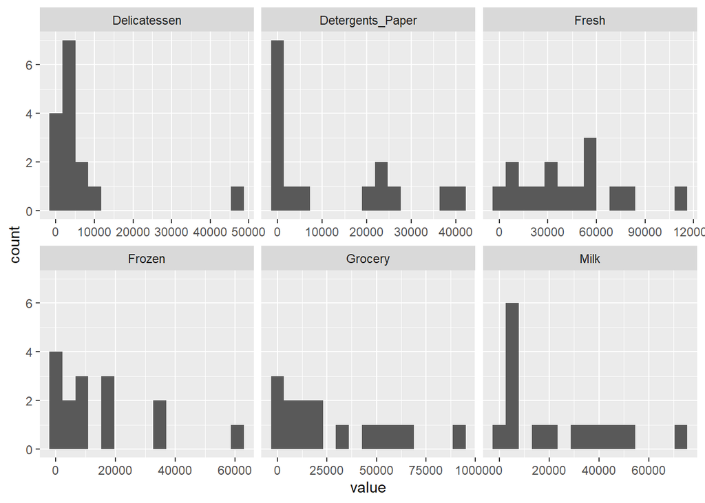

```r
# Converting the data to a key value format and plotting the histograms for the
# 6 categories
cust_data_bin = wholesale %>% filter(Fresh>(max(Fresh)/2) | Milk>(max(Milk)/2)|
                                     Grocery>(max(Grocery)/2)|
                                     Frozen>(max(Frozen)/2)|
                                     Detergents_Paper>(max(Detergents_Paper)/2)|
                                     Delicatessen>(max(Delicatessen)/2)) %>%
  select(Fresh,Milk,Grocery,Frozen,Detergents_Paper,Delicatessen)

ggplot(gather(cust_data_bin), aes(value)) +
  geom_histogram(bins = 15) +
  facet_wrap(~key, scales = 'free_x')
```

##### Cleaning the data by removing the outliers and adding the names for regions and channels:

```r
cust_ol_filt = wholesale %>%
  filter(Fresh<65000,Milk<50000,Grocery<68000,Frozen<30000,
         Detergents_Paper<30000,Delicatessen<20000) %>%
  mutate(region_name = case_when(Region==1 ~ 'Lisbon',Region==2 ~ 'Oporto',
                                 Region==3 ~ 'Other'),
         channel_name = case_when(Channel==1 ~ 'Horeca',
                                  Channel==2 ~ 'Retail'))
```

##### 4.2.2 Data normalization

##### Normalizing the data and plotting the SSE curve for finding the optimum number of clusters:

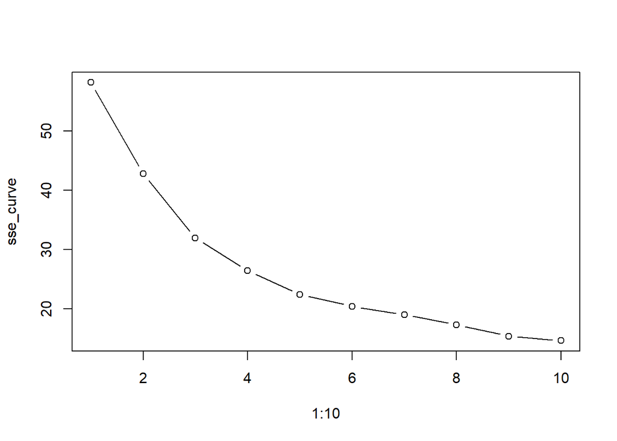

```r
# Using Min-max normalization
normalize = function(x) {
  return((x - min(x)) / (max(x) - min(x)))
}

cust_normalized = cust_ol_filt %>% mutate_at(c(3:8), normalize)
distance_matrix = dist(cust_normalized[,3:8], method = 'euclidean')

sse_curve = c()
for (n in 1:10) {
  cust_kcluster = kmeans(cust_normalized[,3:8], n)
  sse = cust_kcluster$tot.withinss
  sse_curve[n] = sse}
plot(1:10, sse_curve, type = 'b')
```

We are choosing 5 clusters as it has a low SSE value and any cluster size above 5 gives us clusters with very sparse items.

```r
# Performing clustering with 5 clusters
cust_clust = kmeans(cust_normalized[,3:8], centers = 5)
sil_co = silhouette(cust_clust$cluster, dist = distance_matrix)
cust_clust$centers
```

```
##        Fresh       Milk    Grocery     Frozen Detergents_Paper Delicatessen
## 1 0.14003846 0.06850871 0.05900383 0.09188519       0.03280039   0.05497838
## 2 0.17869113 0.57224651 0.51392160 0.11393557       0.53409086   0.20646425
## 3 0.28132427 0.10575531 0.07176205 0.55072830       0.02112433   0.09327399
## 4 0.08211655 0.23592860 0.23510980 0.07504577       0.23191290   0.08494520
## 5 0.53803546 0.10171511 0.09098864 0.14635245       0.04077749   0.13019800
```

```r
summary(sil_co)
```

```
## Silhouette of 430 units in 5 clusters from silhouette.default(x = cust_clust$cluster, dist = distance_matrix) :
##  Cluster sizes and average silhouette widths:
##       210        19        44        95        62
## 0.4377769 0.1282771 0.2600155 0.2449328 0.1886100
## Individual silhouette widths:
##    Min. 1st Qu.  Median    Mean 3rd Qu.    Max.
## -0.2019  0.2057  0.3429  0.3274  0.4831  0.6229
```

##### 4.2.3 Denormalization of values:

Since all the values are from 0 to 1, we are denormalizing them to their actual amounts.

```r
cust_clust_df=as.data.frame.matrix(cust_clust$centers)

# Creating a function for denormalization
denormalize <- function(x,minval,maxval) {
    return(x*(maxval-minval) + minval)}

cust_clust_denorm=data.frame(matrix(ncol = 0, nrow = 5))

# Passing each column and denormalizing the values
for (i in 1:ncol(cust_clust_df)) {
  max_val = max(cust_ol_filt[i+2])
  min_val = min(cust_ol_filt[i+2])
  cust_clust_denorm[i] = denormalize(cust_clust_df[i], min_val, max_val)
}
cust_clust_denorm
```

| Fresh | Milk | Grocery | Frozen | Detergents_Paper | Delicatessen |
| --- | --- | --- | --- | --- | --- |
| 7867.000 | 2679.843 | 3519.333 | 1741.967 | 878.7048 | 911.2429 |
| 10037.579 | 21980.053 | 30630.158 | 2154.000 | 14262.1579 | 3413.7895 |
| 15801.045 | 4106.909 | 4279.659 | 10315.909 | 566.9773 | 1543.8864 |
| 4614.337 | 9094.368 | 14014.368 | 1427.305 | 6194.6105 | 1406.2947 |
| 30216.919 | 3952.113 | 5425.468 | 2759.742 | 1091.6774 | 2153.8710 |

##### 4.2.4 Cluster Results:

● High Fresh and Frozen Spenders: The 44 clients from this group spend more on products from the ‘Fresh’ and ‘Frozen’ category than the other categories and 93% of them are from the Horeca channel.

● Low Spenders: The 210 clients in this group spend less than other clients for all product categories. Among the low spenders, 89% of this group are from the Horeca channel.

● High Fresh Spenders: The 62 clients from this group purchase the most amount within the ‘Fresh’ category amongst all clients compared to other categories. Also, 82% of this group of clients are from the Horeca channel.

● High Grocery Spenders: The 95 clients from this group purchase more products from the ‘Grocery’ category compared to the other categories. 85% of them are from the Retail channel.

### 5. Key Recommendations

● When a client purchases products from one of the ‘Milk’, ‘Detergents’, and ‘Grocery’ categories, recommend products from the other two categories which can lead to increased sales, especially for clients from the Retail channel. For the Horeca channel, it is beneficial to recommend products from the ‘Frozen’ categories when clients purchase products from ‘Delicatessen’. It is imperative to make sure there is no gap in the inventory level of these categories.